# R Intermediate Course 2026

## Running a One-Sample T-Test in R

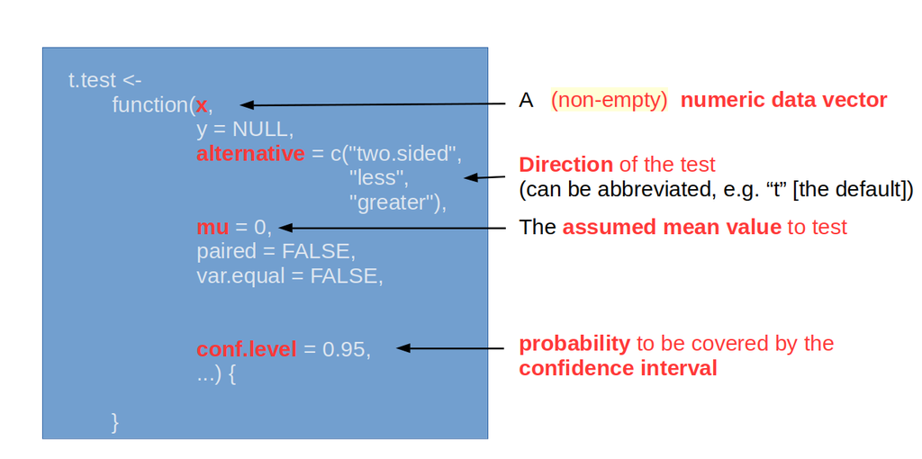

```r
# Is Sepal.Width > 2 in all species jointly?
t.test(x  = iris$Sepal.Width,
       mu = 2)
```

```
    One Sample t-test

data:  iris$Sepal.Width
t = 29.71, df = 149, p-value < 2.2e-16
alternative hypothesis: true mean is not equal to 2
95 percent confidence interval:
 2.987010 3.127656
sample estimates:
mean of x
 3.057333
```

## Running a One-Sample T-Test in R

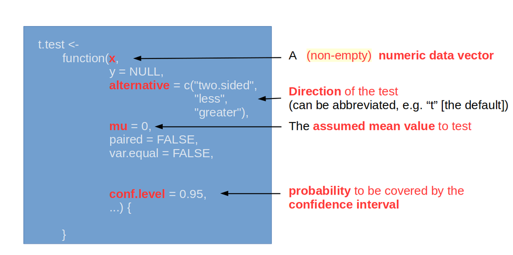

```r
s <- "virginica"
t.test(x  = iris$Sepal.Width[ iris$Species == s ],
       mu = 2) # Can you express it in dplyr style?
```

```
    One Sample t-test

data:  iris$Sepal.Width[iris$Species == s]
t = 21.356, df = 49, p-value < 2.2e-16
alternative hypothesis: true mean is not equal to 2
95 percent confidence interval:
 2.882347 3.065653
sample estimates:
mean of x
    2.974
```

## Running Two-Sample T-Tests in R

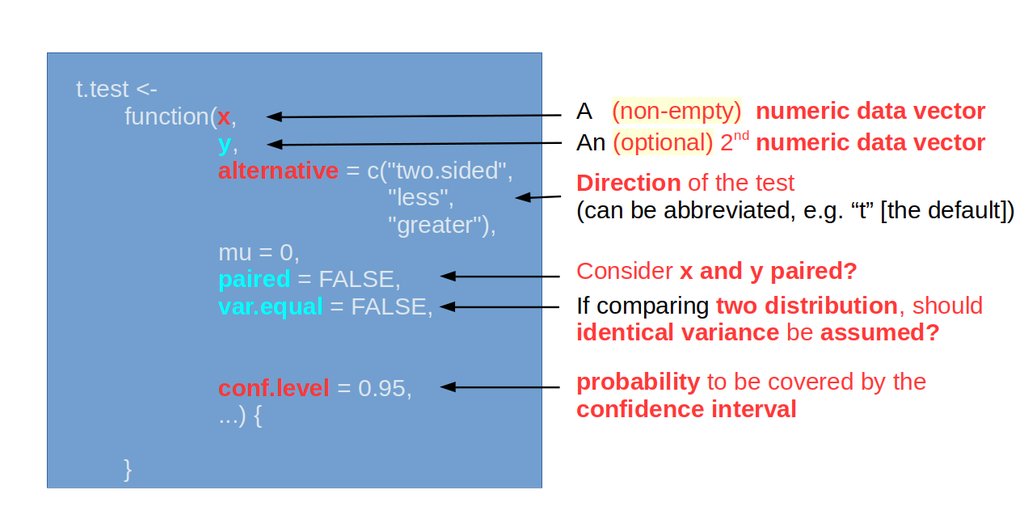

```r
s1 <- "setosa"
s2 <- "versicolor"
t.test(x = iris$Sepal.Width[ iris$Species == s1],
       y = iris$Sepal.Width[ iris$Species == s2],
       paired = FALSE,
       var.equal = TRUE)
```

```
    Two Sample t-test

data:  iris$Sepal.Width[iris$Species == s1] and iris$Sepal.Width[iris$Species == s2]
t = 9.455, df = 98, p-value = 1.845e-15
alternative hypothesis: true difference in means is not equal to 0
95 percent confidence interval:
 0.519895 0.796105
sample estimates:
mean of x mean of y
    3.428     2.770
```

## Running Two-Sample T-Tests in R

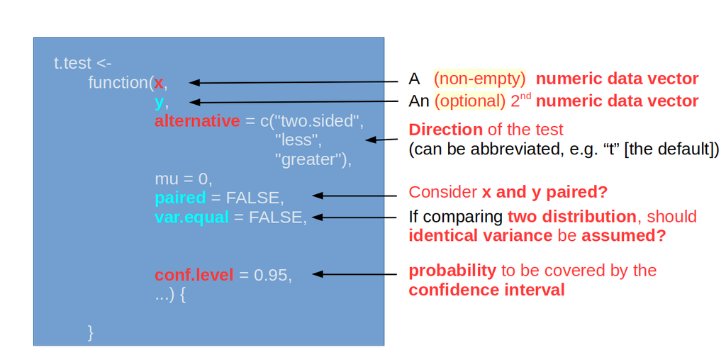

```r
s <- "setosa"
t.test(x = iris$Sepal.Width[ iris$Species == s],
       y = iris$Sepal.Length[ iris$Species == s],
       paired = TRUE,
       var.equal = FALSE)
```

```
    Paired t-test

data:  iris$Sepal.Width[iris$Species == s] and iris$Sepal.Length[iris$Species == s]
t = -42.323, df = 49, p-value < 2.2e-16
alternative hypothesis: true mean difference is not equal to 0
95 percent confidence interval:
 -1.652926 -1.503074
sample estimates:
mean difference
         -1.578
```

## Combine Testing and Pretty Printing

```r
## Define a wrapper function around ggboxplotplot
## (slightly simpler: It computes all possible pairs of group_var's levels and passes them
## (as the list of comparisons to draw) on to stat_compare_means()

require(dplyr)
require(ggplot2)
require(ggpubr)

ggbp <-
     function(data, group_var, test_var, color, palette,
              var.equal=FALSE,
              paired = FALSE) {

         # Construct a list, containing all
         # possible pairs of "group_var"'s levels:
         cmb <-utils::combn(data |>
                            dplyr::pull(group_var) |>
                            levels(),
                            2,
                            # insist to return a *list*!
                            simplify=FALSE
                      )

         ggboxplot(data=data, x = group_var, y = test_var,
                   color = group_var, palette = palette,
                   order = levels(data |> pull(group_var)),
                   ylab = test_var, xlab = group_var) +

             # pass this list to stat_compare:
             stat_compare_means(method = "t.test",
                                paired = paired,
                                method.args =
                                  list(var.equal = var.equal),
                                comparisons = cmb

             )
     }
```

## Combine Testing and Pretty Printing

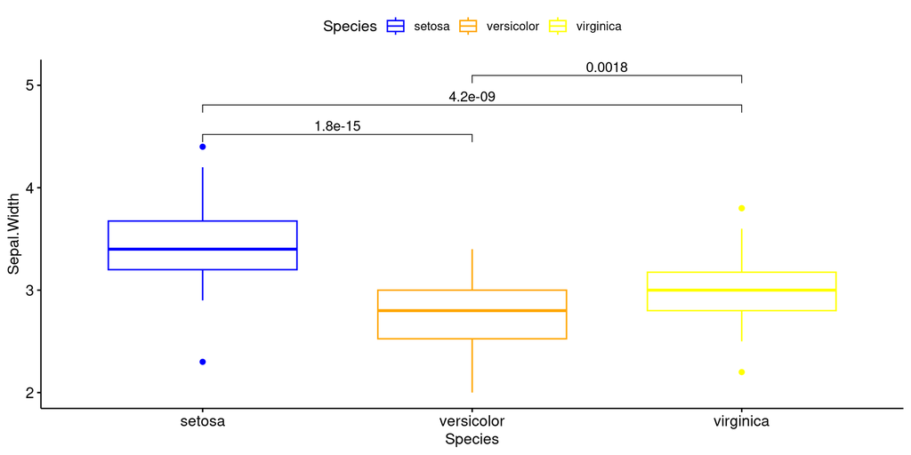

```r
ggbp(data = iris,
     group_var = "Species",
     test_var = "Sepal.Width",
     color = "Species",
     palette = c("blue","orange","yellow"),
     paired = FALSE,

     var.equal = TRUE
     )
```

## A Quick Tour of Concepts: ANOVA

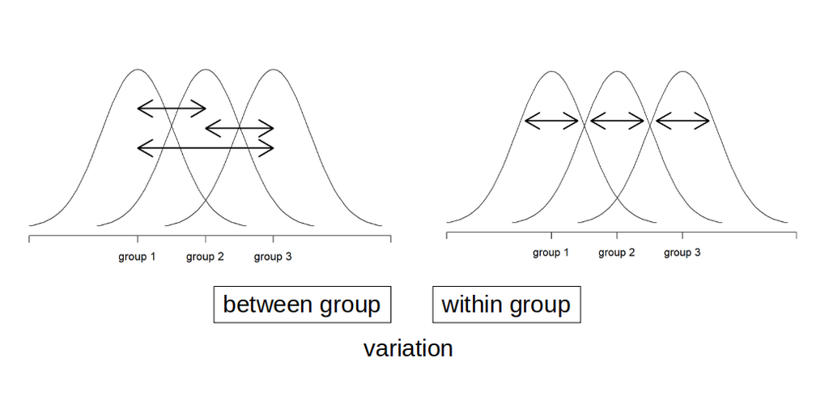

Anova tests the hypothesis: **All of >= 2 group means are identical**.  
For two groups, this is the same as a standard 2-sample t-test.

## A Quick Tour of Concepts: ANOVA

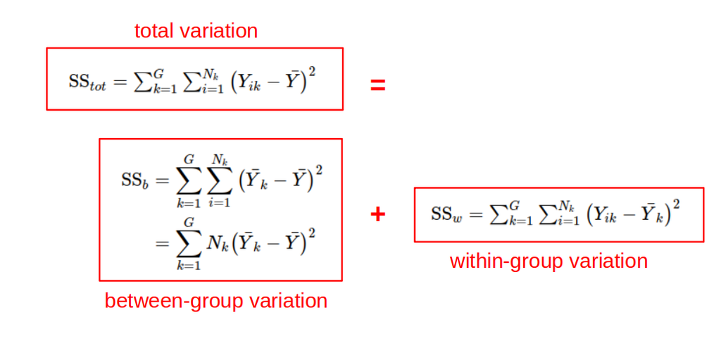

## A Quick Tour of Concepts: ANOVA

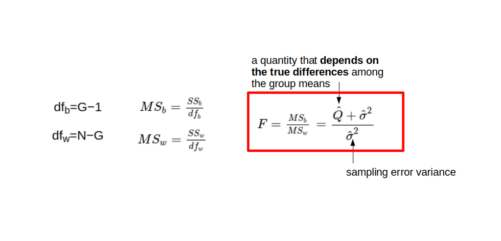

## A Quick Tour of Concepts: ANOVA

**Important**

- A significant F value rejects the **`Null "hypothesis that all means are equal"`**
- One needs to do individual **`pairwise post-hoc t-tests to find the actual differences`**!
- Multiple post-hoc tests need **`multiple testing correction`**

## ANOVA – A Beast in Two Deguises

- Anova as described above answers questions of the kind:  
  “I have data from N sources: Is there any evidence that not all are actually  
  samples from the same underlying population?“
- This type of anova test is implemented by the R functions  
  **stats::aov** and **stats::oneway.test**.
- The second kind is implemented by functions stats::anova and car::Anova.
- It asks: “Given a **linear model** like **Sepal.Width ~ Sepal.Length + Species**,  
  do I actually need both Sepal.Length and Species to describe Sepal.Width,  
  or **can I drop a predictor**?”
- Note that in both cases the goal is **a parsimonious description of the data,**  
  **which nevertheless identifies and keeps true, data-inherent structure**.

## ?aov

[interactive chart not shown]

## oneway.test(): An ANOVA Test Which Can Deal With Unequal Variances

```r
# run_formula_test is defined in R/functions.R
lapply(colnames(iris)[1:4], ## run oneway.test() for each trait
           \(x)run_formula_test(iris, "Species",x,test_f=oneway.test)
  )|>
  bind_rows() |> ## concatenate the results by row
  select(statistic,p.value,group_var,test_var) ## filter outputs to keep
```

```
# A tibble: 4 × 4
  statistic p.value group_var test_var
      <dbl> <chr>   <chr>     <chr>
1     139.  1.5e-28 Species   Sepal.Length
2      45.0 1.4e-14 Species   Sepal.Width
3    1828.  2.7e-66 Species   Petal.Length
4    1277.  4.1e-64 Species   Petal.Width
```

**`The Null Hypothesis of Equality of all Species Means is strongly rejected for all 4 traits`**. However the Petal traits are clearly more species specific than the Sepal trait.

## oneway.test(): An ANOVA Test Which Can Deal With Unequal Variances

**Important**

**Note:** The oneway.test() function expects a formula **lhs ~ rhs**, where **lhs** is a column of normally distributed values, and **rhs** is a column of categorical group labels. The groups so specified need not have equal variance.

```r
oneway.test(Petal.Width ~ Species, data=iris)
```

```
    One-way analysis of means (not assuming equal variances)

data:  Petal.Width and Species
F = 1276.9, num df = 2.000, denom df = 84.951, p-value < 2.2e-16
```

## ?oneway.test

[interactive chart not shown]

## A Quick Tour of Concepts: Linear Regression

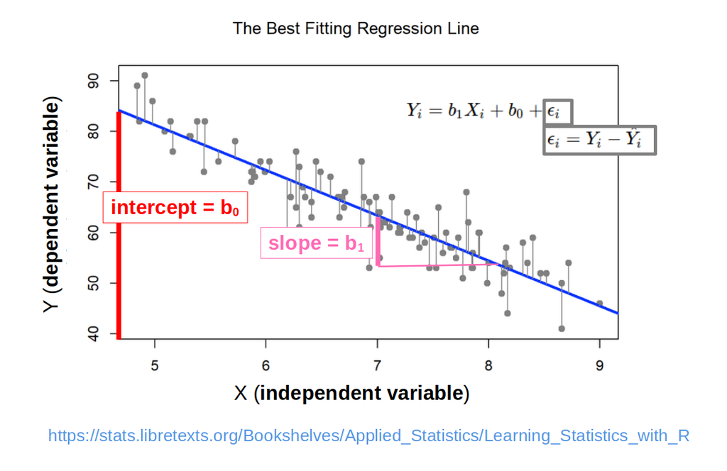

## Multiple Linear Regression

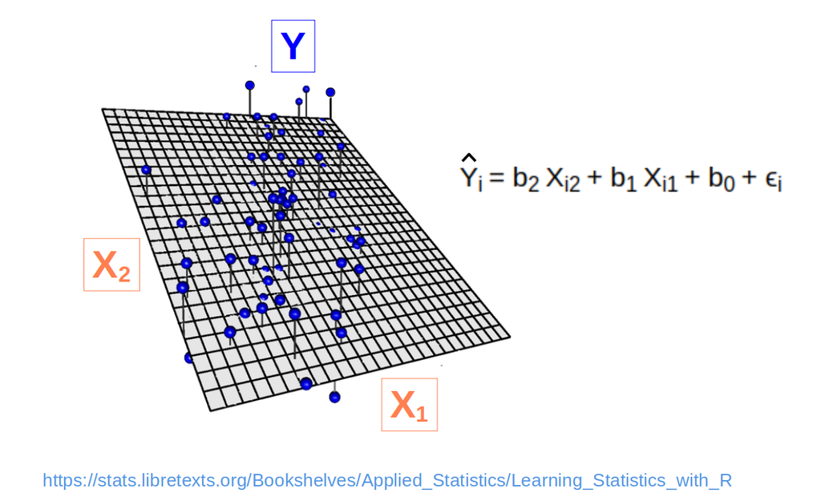

## ?lm

[interactive chart not shown]

## T-test, Anova, and Linear Model

### Comparing Groups: Sepal.Width ~ Species

Sepal.Width meets all assumptions, so we can run a t.test() with `var.equal=TRUE` :

**Important**

At least in **stats::t.test v. 4.4.3, var.equal=FALSE by default!**  
If you insist to assume equal variance, you must set it to TRUE. Better check ?t.test!

```r
iris |>
  dplyr::reframe(t.test(Sepal.Width, var.equal = TRUE) |> broom::tidy(),
                .by=Species)
```

```
     Species estimate statistic      p.value parameter conf.low conf.high            method alternative
1     setosa    3.428  63.94592 7.167044e-49        49 3.320271  3.535729 One Sample t-test   two.sided
2 versicolor    2.770  62.41862 2.310251e-48        49 2.680820  2.859180 One Sample t-test   two.sided
3  virginica    2.974  65.20798 2.780789e-49        49 2.882347  3.065653 One Sample t-test   two.sided
```

Sepal.Width is different from zero with very high probability in all species, but the exact value of the means seem to differ: at least setosa seems to have a clearly higher mean.

## T-test, Anova, and Linear Model

### Comparing Groups: Sepal.Width ~ Species

Does Anova confirm that the means are not equal?

We can use the standard function `aov`, because normality and equal variance hold for this trait.

```r
aov_res <- aov(Sepal.Width ~ Species, data=iris) # keep it for later use
aov_res |> summary() # output the summary only
```

```
             Df Sum Sq Mean Sq F value Pr(>F)
Species       2  11.35   5.672   49.16 <2e-16 ***
Residuals   147  16.96   0.115
---
Signif. codes:  0 '***' 0.001 '**' 0.01 '*' 0.05 '.' 0.1 ' ' 1
```

## T-test, Anova, and Linear Model

### Comparing Groups: Sepal.Width ~ Species

The standard function for post-hoc tests is `stats::TukeyHSD`:  
it is tailored to avoid inflation of significance due to multiple testing.

It assumes normality and equal variance (holds for Sepal.Width). If these assumptions are violated, `rstatix::games_howell_test` can be used as an alternative.

## T-test, Anova, and Linear Model

### Comparing Groups: Sepal.Width ~ Species

You feed TukeyHSD() with the Anova output object:

```r
TukeyHSD(aov_res)
```

```
  Tukey multiple comparisons of means
    95% family-wise confidence level

Fit: aov(formula = Sepal.Width ~ Species, data = iris)

$Species
                       diff         lwr        upr     p adj
versicolor-setosa    -0.658 -0.81885528 -0.4971447 0.0000000
virginica-setosa     -0.454 -0.61485528 -0.2931447 0.0000000
virginica-versicolor  0.204  0.04314472  0.3648553 0.0087802
```

We see that that all pairs of means are significantly different. Notably, setosa has a clearly larger Sepal.Width than both virginica and versicolor.

## T-test, Anova, and Linear Models

### Beyond Bulk Comparison: Model the Data Points Individually

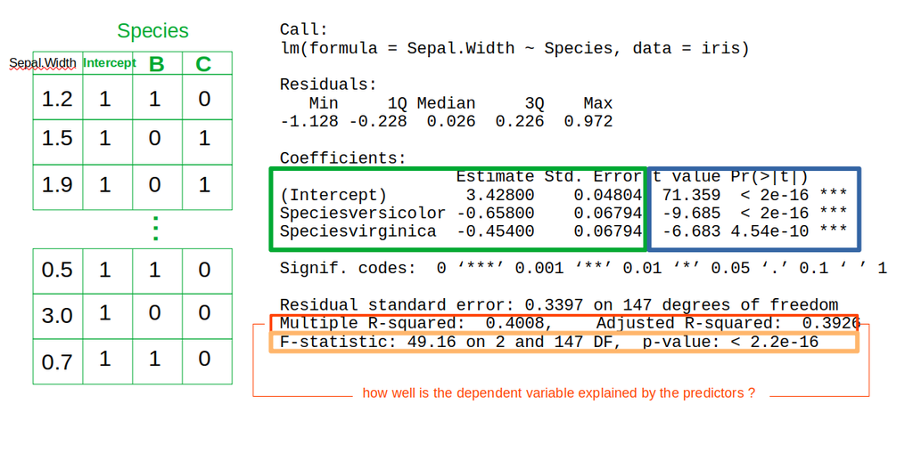

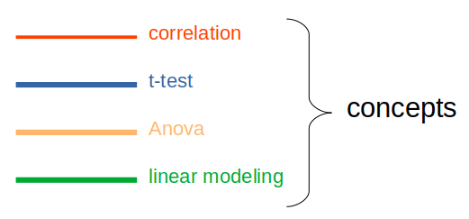

(See also [this](https://bradduthie.github.io/blog/equivalence-of-t-tests-anovas-and-linear-models/) and [that](https://tidyecology.com/posts/linear-models-t-test-anova/) resource on the relation of the t-test, Anova, and the linear model)

## A More Complex Model – Include Sepal.Length (Numeric!)

```r
mod <- lm(Sepal.Width ~ Sepal.Length + Species, data=iris)
```

```r
mod_sum <- summary(mod) # This produces an output in the style of the previous slide
```

```r
mod_sum
```

```
Call:
lm(formula = Sepal.Width ~ Sepal.Length + Species, data = iris)

Residuals:
     Min       1Q   Median       3Q      Max
-0.95096 -0.16522  0.00171  0.18416  0.72918

Coefficients:
                  Estimate Std. Error t value Pr(>|t|)
(Intercept)        1.67650    0.23536   7.123 4.46e-11 ***
Sepal.Length       0.34988    0.04630   7.557 4.19e-12 ***
Speciesversicolor -0.98339    0.07207 -13.644  < 2e-16 ***
Speciesvirginica  -1.00751    0.09331 -10.798  < 2e-16 ***
---
Signif. codes:  0 '***' 0.001 '**' 0.01 '*' 0.05 '.' 0.1 ' ' 1

Residual standard error: 0.289 on 146 degrees of freedom
Multiple R-squared:  0.5693,    Adjusted R-squared:  0.5604
F-statistic: 64.32 on 3 and 146 DF,  p-value: < 2.2e-16
```

## T-test, Anova, and Linear Models

Nearly everything which appears in an lm() output can be extracted:

**Get the Table of Model Coefficient Estimates and T-Test Results:**

```r
# The t-test compares the individual estimates
# against zero
mod_sum$coefficients
```

```
                    Estimate Std. Error    t value     Pr(>|t|)
(Intercept)        1.6765001 0.23535972   7.123139 4.456124e-11
Sepal.Length       0.3498801 0.04630128   7.556598 4.187340e-12
Speciesversicolor -0.9833885 0.07207471 -13.644016 7.620120e-28
Speciesvirginica  -1.0075104 0.09330565 -10.797956 2.406937e-20
```

**Re-compute the t values from Estimate and Standard Error:**

```r
# Note: The numerator is really Estimate - Mean, but here we assume Mean = 0
mod_sum$coefficients[,"Estimate"] / mod_sum$coefficients[,"Std. Error"]
```

```
      (Intercept)      Sepal.Length Speciesversicolor  Speciesvirginica
         7.123139          7.556598        -13.644016        -10.797956
```

## T-test, Anova, and Linear Models

Nearly everything which appears in an lm() output can be extracted:

**Get the F Statistic** (Compares the Entire Model to the Null Model):

```r
mod_sum$fstatistic # lazy style -- just copy it
```

```
    value     numdf     dendf
 64.31529   3.00000 146.00000
```

```r
# Or do it yourself: The total significance of the model is the significance gained
# when comparing to the NULL model (without any predictors):
anova(lm(Sepal.Width ~ 1, data = iris),
      mod)
```

```
Analysis of Variance Table

Model 1: Sepal.Width ~ 1
Model 2: Sepal.Width ~ Sepal.Length + Species
  Res.Df    RSS Df Sum of Sq      F    Pr(>F)
1    149 28.307
2    146 12.193  3    16.114 64.315 < 2.2e-16 ***
---
Signif. codes:  0 '***' 0.001 '**' 0.01 '*' 0.05 '.' 0.1 ' ' 1
```

## T-test, Anova, and Linear Models

Nearly everything which appears in an lm() output can be extracted:

**Get the Model Matrix**

```r
model.matrix(mod) |> head() ## first 6 lines
```

```
  (Intercept) Sepal.Length Speciesversicolor Speciesvirginica
1           1          5.1                 0                0
2           1          4.9                 0                0
3           1          4.7                 0                0
4           1          4.6                 0                0
5           1          5.0                 0                0
6           1          5.4                 0                0
```

```r
model.matrix(mod)[50:55,]  ## middle 6 lines
```

```
   (Intercept) Sepal.Length Speciesversicolor Speciesvirginica
50           1          5.0                 0                0
51           1          7.0                 1                0
52           1          6.4                 1                0
53           1          6.9                 1                0
54           1          5.5                 1                0
55           1          6.5                 1                0
```

```r
model.matrix(mod) |> tail() ## last 6 lines
```

```
    (Intercept) Sepal.Length Speciesversicolor Speciesvirginica
145           1          6.7                 0                1
146           1          6.7                 0                1
147           1          6.3                 0                1
148           1          6.5                 0                1
149           1          6.2                 0                1
150           1          5.9                 0                1
```

## Refining a Model: The Role of Sepal.Length

```r
mod_sum
```

```
Call:
lm(formula = Sepal.Width ~ Sepal.Length + Species, data = iris)

Residuals:
     Min       1Q   Median       3Q      Max
-0.95096 -0.16522  0.00171  0.18416  0.72918

Coefficients:
                  Estimate Std. Error t value Pr(>|t|)
(Intercept)        1.67650    0.23536   7.123 4.46e-11 ***
Sepal.Length       0.34988    0.04630   7.557 4.19e-12 ***
Speciesversicolor -0.98339    0.07207 -13.644  < 2e-16 ***
Speciesvirginica  -1.00751    0.09331 -10.798  < 2e-16 ***
---
Signif. codes:  0 '***' 0.001 '**' 0.01 '*' 0.05 '.' 0.1 ' ' 1

Residual standard error: 0.289 on 146 degrees of freedom
Multiple R-squared:  0.5693,    Adjusted R-squared:  0.5604
F-statistic: 64.32 on 3 and 146 DF,  p-value: < 2.2e-16
```

## Refining a Model: The Role Sepal.Length

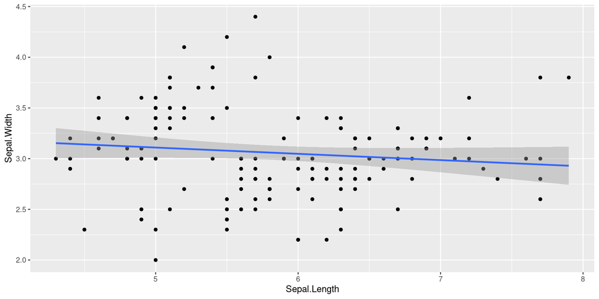

```r
ggplot2::ggplot(
  iris,
  aes(y=Sepal.Width,
      x=Sepal.Length
    )
)+geom_point()+
  geom_smooth(method="lm")
```

## Refining a Model: The Role of Sepal.Length

```r
lm(Sepal.Width ~ Sepal.Length, data = iris) |> summary()
```

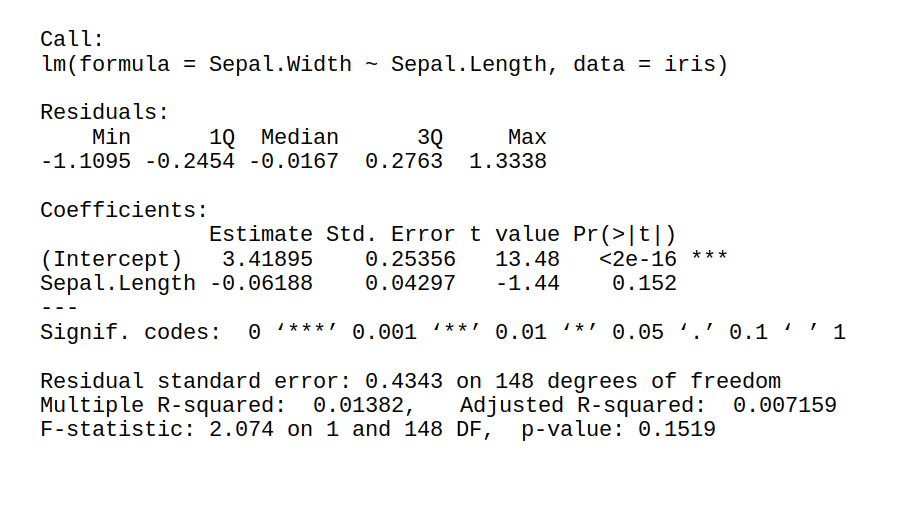

No significant relation ?

## Refining a Model: The Role of Sepal.Length

```r
lm(Sepal.Width ~ Sepal.Length + Species, data = iris) |> summary()
```

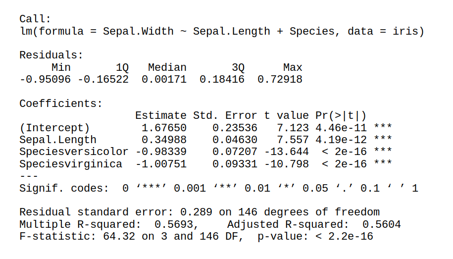

## Refining a Model: The Role of Sepal.Length – and Species!

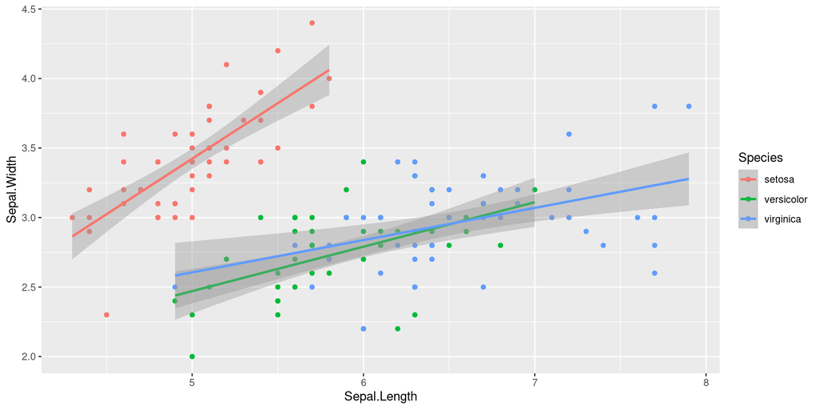

```r
ggplot2::ggplot(
  iris,
  aes(y=Sepal.Width,
      x=Sepal.Length,
      color = Species
    )
)+geom_point()+
  geom_smooth(method="lm")
```

**NOTE**: Written like this, it `seems to fit the line of each species individually`!

## Refining a Model: The Role of Sepal.Length – and Species!

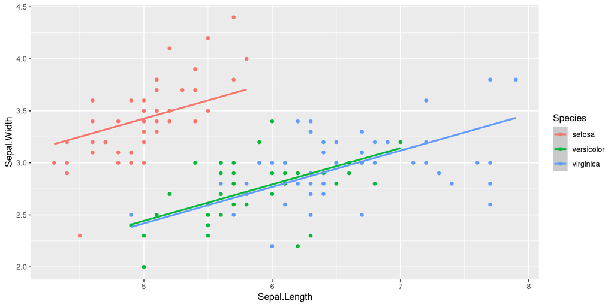

```r
mdl <-
  lm(formula = Sepal.Width ~ Sepal.Length + Species,
     data=iris)

ggplot2::ggplot(
  iris,
  aes(y=Sepal.Width,
      x=Sepal.Length,
      color = Species
    )
)+geom_point()+
  geom_smooth(method="lm",
              mapping=aes(y=predict(mdl,iris))
  )
```

**`This draws what our model actually computes:`**

- a **common slope** (the Sepal.Length factor)
- and **y-offsets relative to Species=setosa** for versicolor and virginica

**`?`** But how to add confidence bands in this case **`?`**

## Refining a Model: The Role of Sepal.Length – and Species!

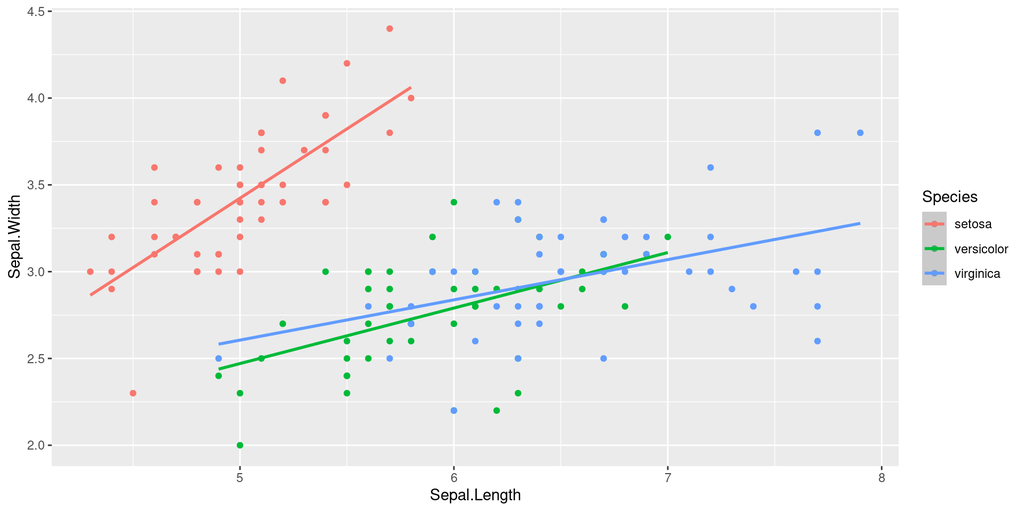

```r
mdl <-
  lm(formula = Sepal.Width ~ Sepal.Length * Species,
     data=iris)

ggplot2::ggplot(
  iris,
  aes(y=Sepal.Width,
      x=Sepal.Length,
      color = Species
    )
)+geom_point()+
  geom_smooth(method="lm",
              mapping=aes(y=predict(mdl,iris))
  )
```

Now with an interaction (* instead of +) !

So ggplot got it right from the start …

## Last Topic Just Scratched: Anova for Comparing Models

The `base::anova()` and `car::Anova()` functions can do more than checking  
whether group means are equal:

- they can help to streamline an entire model,
- by testing the variance explained by the individual predictors of the model (e.g. “Sepal.Length” and “Species” above).
- **Predictors with a non-significant contribution can be dropped**

## Last Topic Just Scratched: Anova for Comparing Models

`anova`() is meant for **balanced data (same number of observations for each group)**.  
When passed

- a **single result object of a modelling function**, it will
  - start with the Null model,
  - then add the predictors in the order in which they appear in the model
  - report the significance gained or lost at each step

```r
# "Sum Sq" (Sum of Squares) is the amount of variance
# explained by adding the predictor to the model,
# given all other predictors already added.
anova(lm(Sepal.Width ~ Sepal.Length + Species,
         data=iris))
```

```
Analysis of Variance Table

Response: Sepal.Width
              Df  Sum Sq Mean Sq F value  Pr(>F)
Sepal.Length   1  0.3913  0.3913  4.6851 0.03205 *
Species        2 15.7225  7.8613 94.1304 < 2e-16 ***
Residuals    146 12.1931  0.0835
---
Signif. codes:  0 '***' 0.001 '**' 0.01 '*' 0.05 '.' 0.1 ' ' 1
```

## Last Topic Just Scratched: Anova for Comparing Models

`anova`() is meant for **balanced data (same number of observations for each group)**.  
When passed

- a **single result object of a modelling function**, it will
  - start with the Null model,
  - then add the predictors in the order in which they appear in the model
  - report the significance gained or lost at each step

```r
anova(lm(Sepal.Width ~ Sepal.Length + Species,
         data=iris))
```

```
Analysis of Variance Table

Response: Sepal.Width
              Df  Sum Sq Mean Sq F value  Pr(>F)
Sepal.Length   1  0.3913  0.3913  4.6851 0.03205 *
Species        2 15.7225  7.8613 94.1304 < 2e-16 ***
Residuals    146 12.1931  0.0835
---
Signif. codes:  0 '***' 0.001 '**' 0.01 '*' 0.05 '.' 0.1 ' ' 1
```

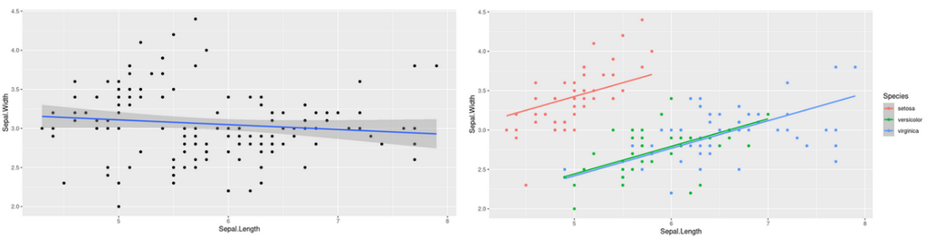

## Last Topic Just Scratched: Anova for Comparing Models

`anova`() is meant for **balanced data (same number of observations for each group)**.  
When passed

- two or more separate objects, it will
  - compare them sequentially: 2 to 1, 3 to 2, …

This makes most sense if the models are nested: models **later in the list** contains **all predictors** of earlier models, **plus some more**.

```r
# "Sum of Sq" (Sum of Squares) is the amount of variance
# explained by adding the predictor to the model,
# given all other predictors already added.

anova(lm(Sepal.Width ~ 1, # means: "Intercept only"
         data=iris),
      lm(Sepal.Width ~ Species,
         data=iris),
      lm(Sepal.Width ~ Species + Sepal.Length ,
         data=iris))
```

```
Analysis of Variance Table

Model 1: Sepal.Width ~ 1
Model 2: Sepal.Width ~ Species
Model 3: Sepal.Width ~ Species + Sepal.Length
  Res.Df    RSS Df Sum of Sq      F    Pr(>F)
1    149 28.307
2    147 16.962  2   11.3449 67.922 < 2.2e-16 ***
3    146 12.193  1    4.7689 57.102 4.187e-12 ***
---
Signif. codes:  0 '***' 0.001 '**' 0.01 '*' 0.05 '.' 0.1 ' ' 1
```

## Last Topic Just Scratched: Anova for Comparing Models

`anova`() is meant for **balanced data (same number of observations for each group)**.  
When passed

- two or more separate objects, it will
  - compare them sequentially: 2 to 1, 3 to 2, …

This makes most sense if the models are nested: models **later in the list** contains **all predictors** of earlier models, **plus some more**.

This gives you essentially the same result:

```r
anova(lm(Sepal.Width ~ Species + Sepal.Length ,
         data=iris))
```

```
Analysis of Variance Table

Response: Sepal.Width
              Df  Sum Sq Mean Sq F value    Pr(>F)
Species        2 11.3449  5.6725  67.922 < 2.2e-16 ***
Sepal.Length   1  4.7689  4.7689  57.102 4.187e-12 ***
Residuals    146 12.1931  0.0835
---
Signif. codes:  0 '***' 0.001 '**' 0.01 '*' 0.05 '.' 0.1 ' ' 1
```

## ?anova.lm

[interactive chart not shown]

## Last Topic Just Scratched: Anova for Comparing Models

**car::Anova**() has **less restrictions** than stats::anova():

- It can deal with unbalanced data
- It computes “Type-II” or “Type-III” analysis-of-variance tables
  - **Type-II [default]**: Test each term after all others, `but` “omit a term’s higher-order relatives”
  - **Type-III**: Test each term after `all` others **[the help page cautions against this]**
  - These strategies assure that each test asks the question:  
    **Will this added term detect additional structure**, not already detected by the other terms?

(See also [here](https://rcompanion.org/rcompanion/d_04.html))

## Last Topic Just Scratched: Anova for Comparing Models

Compare:

stats::anova()

```r
anova(lm(Sepal.Width ~ Sepal.Length + Species,
         data=iris))
```

```
Analysis of Variance Table

Response: Sepal.Width
              Df  Sum Sq Mean Sq F value  Pr(>F)
Sepal.Length   1  0.3913  0.3913  4.6851 0.03205 *
Species        2 15.7225  7.8613 94.1304 < 2e-16 ***
Residuals    146 12.1931  0.0835
---
Signif. codes:  0 '***' 0.001 '**' 0.01 '*' 0.05 '.' 0.1 ' ' 1
```

If tested alone against the NULL model, **Sepal.Length has marginal effect**.

car::Anova()

```r
car::Anova(lm(Sepal.Width ~ Sepal.Length + Species,
              data=iris))
```

```
Anova Table (Type II tests)

Response: Sepal.Width
              Sum Sq  Df F value    Pr(>F)
Sepal.Length  4.7689   1  57.102 4.187e-12 ***
Species      15.7225   2  94.130 < 2.2e-16 ***
Residuals    12.1931 146
---
Signif. codes:  0 '***' 0.001 '**' 0.01 '*' 0.05 '.' 0.1 ' ' 1
```

If tested against a model which already contains Species, it becomes evident that **Sepal.Length helps “things fall in place”**: Its relative contribution is now much higher.

## ?car::Anova

[interactive chart not shown]

## THE END !

[figure not shown]